# LCL top-10 co-accessibility: donor accessibility and pooled m6A proportions

Crystal Shan

# Analysis overview

This extends from the preivous co-acessibility analysis in `/project/spott/cshan/fiber-seq/code/co-accessibility/LCL/CRE_co-accessibility_FIRE/LCL_co-access.Rmd` I preivously used Fisher exact to test if the CRE pairs are more often co-accessible than expected, but there is high donor heterogeneity, the CRE pairs accessible in one donor may not be accessible in another. This might be a problem because:

- mixing donor creates an assoication

Permutation test shuffles CRE2 m6A proportions only within each sample

- Each fiber (one sequenced DNA molecule) has a pair of numbers: its m6A proportion at CRE1 (prop1) and at CRE2 (prop2)
- Within each sample, the permutation randomly reassigns the prop2 values among that sample’s fibers prop1 and the sample labels stay fixed

The `pooled` analysis includes all 31 samples and the `noXCI` analysis uses the existing noXCI results and sex assignments: chrX uses male samples only, and all other chromosomes use all 31 samples

For each cCRE, `assemble_region_m6a(full_span = TRUE, positions = NULL)` builds one read × position matrix for the included samples - from this, we get positions with at least one observed m6A call among those pooled full span reads

Fraction of positions that methylated (counts positions with at least one observed m6a call across all pooled reads, reflects methylated positions out of observed positions)

- `prop1 = rowSums(CRE1_matrix) / ncol(CRE1_matrix)` and `prop2 = rowSums(CRE2_matrix) / ncol(CRE2_matrix)`.

# Setup and inputs

```r
coaccess_dir <- file.path(params$root, "coaccess")
universe_dir <- file.path(params$root, "universe")
analysis_sets <- c("pooled", "noXCI")
stopifnot(params$n_permutations == 10000L)
state_columns <- c("co_access", "CRE1_access", "CRE2_access", "co_closed")
state_labels <- setNames(CONFIG_LEVELS, state_columns)
fire_overlap_fraction <- 0.5

# output directories
out_dir <- file.path(params$root, "co-access_v2_perm_methy_prop")
table_dir <- file.path(out_dir, "tables")
plot_dir <- file.path(out_dir, "plots")
for (d in c(table_dir, plot_dir)) dir.create(d, recursive = TRUE, showWarnings = FALSE)
# Existing results are preserved: files already on disk are never overwritten.
existing <- c(list.files(table_dir), list.files(plot_dir))
if (length(existing))
  cat(length(existing), "existing output files will be kept; only missing files are written\n")
```

```
## 22 existing output files will be kept; only missing files are written
```

```r
write_table <- function(x, name) {
  path <- file.path(table_dir, name)
  if (file.exists(path)) {
    message("Kept existing ", path)
    return(invisible(path))
  }
  fwrite(x, path, sep = "\t", na = "NA")
  invisible(path)
}
final_plots <- list()
queue_plot <- function(p, name, width = 13, height = 10) {
  final_plots[[name]] <<- list(plot = p, width = width, height = height)
}
cat("Results directory:", out_dir, "\n")
```

```
## Results directory: /project/spott/cshan/fiber-seq/LCL_project/co-accessibility/CRE_co-accessibility_FIRE/co-access_v2_perm_methy_prop
```

```r
sample_meta <- fread(params$sample_sheet)
manifest <- fread(file.path(universe_dir, "sample_manifest.tsv"))
run_manifest <- fread(file.path(coaccess_dir, "sample_manifest.tsv"))
stopifnot(nrow(sample_meta) == 31L, nrow(manifest) == 31L,
          nrow(run_manifest) == 31L,
          !anyDuplicated(sample_meta$sample_name), !anyDuplicated(manifest$sample_name),
          !anyDuplicated(run_manifest$sample_name),
          setequal(sample_meta$sample_name, manifest$sample_name),
          setequal(run_manifest$sample_name, manifest$sample_name))
samples <- as.character(manifest$sample_name)
sample_meta <- sample_meta[match(samples, sample_name)]
sample_meta[, donor := as.character(cell_line)]
run_manifest <- run_manifest[match(samples, sample_name)]
stopifnot(identical(as.character(manifest$donor), sample_meta$donor))
provenance_columns <- c("sample_name", "donor", "fire_dir", "cram_path",
                        "elements_path", "spans_path")
for (column in provenance_columns) {
  if (!identical(as.character(run_manifest[[column]]), as.character(manifest[[column]])))
    stop("Universe and completed-run manifests differ in ", column)
}
same_paths <- function(a, b)
  identical(normalizePath(a, mustWork = TRUE), normalizePath(b, mustWork = TRUE))
stopifnot(same_paths(manifest$fire_dir, file.path(params$fire_root, samples)),
          same_paths(run_manifest$blocks_path,
            file.path(params$root, samples, paste0(samples, ".aligned_blocks.bed.gz"))),
          same_paths(run_manifest$elements_path,
            file.path(params$fire_root, samples, "additional-outputs-v0.1", "fire-peaks",
                      paste0(samples, "-v0.1-fire-elements.bed.gz"))),
          file.exists(params$tabix))
sample_table <- as.data.frame(manifest[, .(sample_name, fire_dir)])
donors <- unique(sample_meta$donor)
male_samples <- character()
if ("noXCI" %in% analysis_sets) {
  sex_noxci <- fread(file.path(coaccess_dir, "noXCI", "LCL_sample_sex_noXCI.tsv"))
  stopifnot(nrow(sex_noxci) == 31L, !anyDuplicated(sex_noxci$sample_name),
            setequal(sex_noxci$sample_name, samples),
            all(sex_noxci$sex %in% c("male (XY)", "female (XX)")),
            identical(as.character(sex_noxci$donor[match(samples, sex_noxci$sample_name)]),
                      sample_meta$donor))
  male_samples <- samples[samples %in% sex_noxci[sex == "male (XY)", sample_name]]
  stopifnot(length(male_samples) > 0L)
}
```

## Load the top ten co-accessible pairs (ranked by FDR)

Both top-ten sets are loaded from the tables saved by `LCL/CRE_co-accessibility_FIRE/LCL_co-access.Rmd` in `coaccess/`:

- `LCL_top10_pairs.tsv` (pooled) and `LCL_top10_pairs_noXCI.tsv` (female chrx removed)

```r
top10_files <- c(pooled = file.path(coaccess_dir, "LCL_top10_pairs.tsv"),
                 noXCI = file.path(coaccess_dir, "LCL_top10_pairs_noXCI.tsv"))
selected_sets <- setNames(lapply(analysis_sets, function(a) {
  chosen <- fread(top10_files[[a]])
  chosen[, `:=`(analysis = a, pair_rank = seq_len(.N))]
  chosen
}), analysis_sets)
selected <- rbindlist(selected_sets, fill = TRUE)

print(head(selected[, .(analysis, pair_rank, pair_id, CRE_pair, gene_names)]))
```

```
##    analysis pair_rank                       pair_id
##      <char>     <int>                        <char>
## 1:   pooled         1   top1_chrX_77894378_77900509
## 2:   pooled         2 top2_chrX_135519482_135523030
## 3:   pooled         3 top3_chrX_149502503_149506532
## 4:   pooled         4   top4_chrX_73850175_73853902
## 5:   pooled         5  top5_chr14_57492840_57496756
## 6:   pooled         6 top6_chrX_123959245_123964346
##                                                        CRE_pair
##                                                          <char>
## 1:  EH38D6116107.EH38E3938024.PLS-EH38D4291982.EH38E2759288.PLS
## 2: EH38D4314319.EH38E2770283.PLS-EH38D6133435.EH38E3946048.pELS
## 3: EH38D6137338.EH38E3947664.pELS-EH38D6137342.EH38E3947668.PLS
## 4: EH38D4290809.EH38E2758712.pELS-EH38D6115046.EH38E3937596.PLS
## 5: EH38D2723022.EH38E1717288.PLS-EH38D2723025.EH38E1717290.pELS
## 6: EH38D6129234.EH38E3943839.PLS-EH38D4308736.EH38E2767243.pELS
##              gene_names
##                  <char>
## 1:          COX7B;MAGT1
## 2:    INTS6L;INTS6L-AS1
## 3:                  IDS
## 4: ENSG00000278039;XIST
## 5:              CCDC198
## 6:      STAG2;STAG2-AS1
```

for a set of selected cCRE pairs, pull each pair’s per-sample count tables

- extract pair information from `LCL_pair_sample_counts.tsv.gz`

```r
# extract pair information
read_selected_counts <- function(path, pair_ids) {
  con <- gzfile(path, "rt")
  on.exit(close(con))
  header <- readLines(con, n = 1L)
  out <- list()
  repeat {
    lines <- readLines(con, n = 100000L)
    if (!length(lines)) break
    ids <- substr(lines, 1L, regexpr("\t", lines, fixed = TRUE) - 1L)
    lines <- lines[ids %in% pair_ids]
    if (length(lines)) out[[length(out) + 1L]] <-
      fread(text = paste(c(header, lines), collapse = "\n"), sep = "\t")
  }
  rbindlist(out)
}
counts_file <- file.path(coaccess_dir, "LCL_pair_sample_counts.tsv.gz")
sample_counts <- read_selected_counts(counts_file, unique(selected$CRE_pair))
stopifnot(!anyDuplicated(sample_counts[, .(CRE_pair, sample_name)]),
          all(sample_counts$sample_name %in% samples),
          all(sample_counts$donor == sample_meta$donor[match(sample_counts$sample_name, samples)]),
          all(rowSums(as.matrix(sample_counts[, ..state_columns])) == sample_counts$n_shared_reads))

# pick which sample counts
  # if we are excluding female chrx, restrict it to male samples
pair_samples_for <- function(pair) {
  if (pair$analysis == "noXCI" && pair$chrom == "chrX") male_samples else samples
}

# subset to the CRE pair and the sample included
counts_for <- function(pair) {
  included <- pair_samples_for(pair)
  z <- sample_counts[CRE_pair == pair$CRE_pair & sample_name %in% included]
  stopifnot(nrow(z) == length(included), setequal(z$sample_name, included),
            all(z$chrom == pair$chrom))
  z <- copy(z[match(included, sample_name)])
  suffix <- if (pair$analysis == "noXCI") "_noXCI" else ""
  for (column in c(state_columns, "n_shared_reads"))
    if (sum(z[[column]]) != pair[[paste0(column, suffix)]])
      stop("Saved sample counts disagree with pooled Fisher table: ", pair$pair_id, " / ", column)
  z[, `:=`(analysis = pair$analysis, pair_id = pair$pair_id, pair_rank = pair$pair_rank)]
  z
}

selected_sample_counts <- rbindlist(lapply(seq_len(nrow(selected)), function(i) counts_for(selected[i])))

print(head(selected_sample_counts))
```

```
##                                                       CRE_pair co_closed
##                                                         <char>     <int>
## 1: EH38D6116107.EH38E3938024.PLS-EH38D4291982.EH38E2759288.PLS         1
## 2: EH38D6116107.EH38E3938024.PLS-EH38D4291982.EH38E2759288.PLS         0
## 3: EH38D6116107.EH38E3938024.PLS-EH38D4291982.EH38E2759288.PLS         0
## 4: EH38D6116107.EH38E3938024.PLS-EH38D4291982.EH38E2759288.PLS         2
## 5: EH38D6116107.EH38E3938024.PLS-EH38D4291982.EH38E2759288.PLS         0
## 6: EH38D6116107.EH38E3938024.PLS-EH38D4291982.EH38E2759288.PLS         4
##    CRE1_access CRE2_access co_access  chrom       sample_name   donor
##          <int>       <int>     <int> <char>            <char>  <char>
## 1:           0           0         2   chrX  AL6_bc2162_19093 NA19093
## 2:           0           0         4   chrX  AL8_bc2170_19151 NA19151
## 3:           0           0         2   chrX AL10_bc2178_19130 NA19130
## 4:           0           0         4   chrX AL16_bc2114_18508 NA18508
## 5:           0           0         3   chrX AL18_bc2130_18504 NA18504
## 6:           0           1         1   chrX AL19_bc2138_18861 NA18861
##    n_shared_reads analysis                     pair_id pair_rank
##             <int>   <char>                      <char>     <int>
## 1:              3   pooled top1_chrX_77894378_77900509         1
## 2:              4   pooled top1_chrX_77894378_77900509         1
## 3:              2   pooled top1_chrX_77894378_77900509         1
## 4:              6   pooled top1_chrX_77894378_77900509         1
## 5:              3   pooled top1_chrX_77894378_77900509         1
## 6:              6   pooled top1_chrX_77894378_77900509         1
```

# Donor accessibility

For each donor, observed co-accessibility is `co_access`, expected co-accessibility under independence is `(co_access + CRE1_access) * (co_access + CRE2_access) / N`, where `N` is the donor’s total shared reads Fractions divide these counts by `N`

```r
# add the counts for each donor and each pair (each pair can have multiple donors)
donor_accessibility <- selected_sample_counts[, lapply(.SD, sum),
  by = .(analysis, pair_id, pair_rank, CRE_pair, donor),
  .SDcols = c(state_columns, "n_shared_reads")]

# calculate expected co-accessibility for each donor, and the fraction of CRE1/2 being accessible and the fraction of them co-accessible
donor_accessibility[, `:=`(
  observed_co_access = co_access,
  expected_co_access = fifelse(n_shared_reads > 0,
    expected_coaccess(co_closed, CRE1_access, CRE2_access, co_access), NA_real_))]
donor_accessibility[, `:=`(
  observed_fraction = fifelse(n_shared_reads > 0, co_access / n_shared_reads, NA_real_),
  expected_fraction = fifelse(n_shared_reads > 0, expected_co_access / n_shared_reads, NA_real_),
  observed_expected_ratio = fifelse(expected_co_access > 0, co_access / expected_co_access, NA_real_))]

# loop over "co_access", "CRE1_access", "CRE2_access", "co_closed" and calculate the fraction
for (state in state_columns)
  donor_accessibility[, (paste0(state, "_fraction")) :=
    fifelse(n_shared_reads > 0, get(state) / n_shared_reads, NA_real_)]

donor_states <- melt(donor_accessibility,
  id.vars = c("analysis", "pair_id", "pair_rank", "CRE_pair", "donor", "n_shared_reads"),
  measure.vars = state_columns, variable.name = "state", value.name = "n_fibers")
donor_states[, `:=`(config = factor(state_labels[as.character(state)], levels = CONFIG_LEVELS),
                    fraction = fifelse(n_shared_reads > 0, n_fibers / n_shared_reads, NA_real_))]

print(head(donor_states))
```

```
##    analysis                     pair_id pair_rank
##      <char>                      <char>     <int>
## 1:   pooled top1_chrX_77894378_77900509         1
## 2:   pooled top1_chrX_77894378_77900509         1
## 3:   pooled top1_chrX_77894378_77900509         1
## 4:   pooled top1_chrX_77894378_77900509         1
## 5:   pooled top1_chrX_77894378_77900509         1
## 6:   pooled top1_chrX_77894378_77900509         1
##                                                       CRE_pair   donor
##                                                         <char>  <char>
## 1: EH38D6116107.EH38E3938024.PLS-EH38D4291982.EH38E2759288.PLS NA19093
## 2: EH38D6116107.EH38E3938024.PLS-EH38D4291982.EH38E2759288.PLS NA19151
## 3: EH38D6116107.EH38E3938024.PLS-EH38D4291982.EH38E2759288.PLS NA19130
## 4: EH38D6116107.EH38E3938024.PLS-EH38D4291982.EH38E2759288.PLS NA18508
## 5: EH38D6116107.EH38E3938024.PLS-EH38D4291982.EH38E2759288.PLS NA18504
## 6: EH38D6116107.EH38E3938024.PLS-EH38D4291982.EH38E2759288.PLS NA18861
##    n_shared_reads     state n_fibers          config  fraction
##             <int>    <fctr>    <int>          <fctr>     <num>
## 1:              3 co_access        2 both accessible 0.6666667
## 2:              4 co_access        4 both accessible 1.0000000
## 3:              2 co_access        2 both accessible 1.0000000
## 4:              6 co_access        4 both accessible 0.6666667
## 5:              3 co_access        3 both accessible 1.0000000
## 6:              6 co_access        1 both accessible 0.1666667
```

### accessibility status by donor

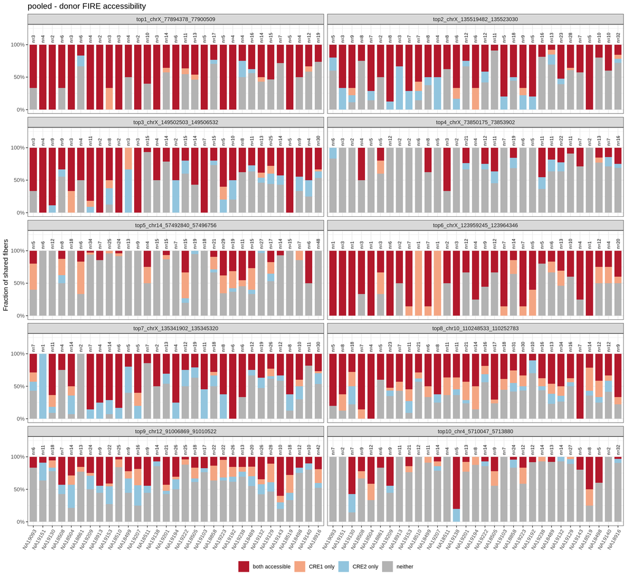

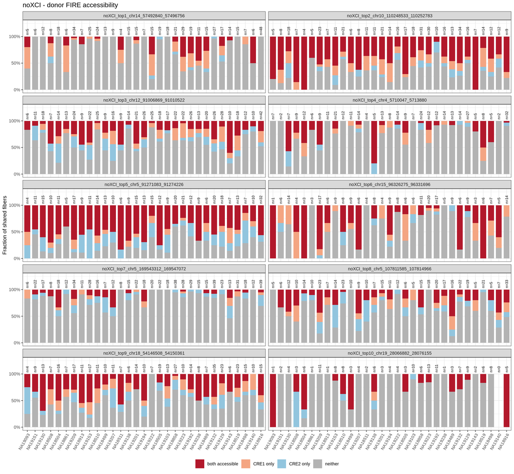

```r
if (isTRUE(params$make_plots)) for (a in analysis_sets) {
  d <- copy(donor_states[analysis == a])
  d[, donor := factor(donor, levels = donors)]
  d[, pair_id := factor(pair_id, levels = selected_sets[[a]]$pair_id)]
  totals <- unique(d[, .(pair_id, donor, n_shared_reads)])
  totals[, lab := paste0("n=", n_shared_reads)]
  p <- plot_stacked_proportion(d[n_shared_reads > 0], "donor", "config", CONFIG_COLS,
    y = "fraction", position = "stack",
    totals = list(data = totals, x = "donor", y = 1.03, label = "lab",
                  style = list(size = 2.3, angle = 90, hjust = 0)),
    scales = list(scale_y_continuous(labels = scales::label_percent(),
                                    breaks = c(0, 0.5, 1), limits = c(0, 1.25)),
                  scale_x_discrete(drop = FALSE)),
    labels = list(x = NULL, y = "Fraction of shared fibers", title = paste(a, "- donor FIRE accessibility")),
    legend = list(name = NULL, drop = FALSE),
    theme = theme_fiberseq("bw", base_size = 10,
      overrides = list(axis.text.x = element_text(angle = 60, hjust = 1),
                       legend.position = "bottom"))) + facet_wrap(~pair_id, ncol = 2)
  print(p)
  queue_plot(p, paste0(a, "_donor_accessibility"), height = 12)
}
```

## calculate m6a (methylation) proportion at each selected pair

how much m6A methylation does each fiber have inside each cCRE? That makes it possible to test whether a fiber with high m6A at CRE1 also tends to have high m6A at CRE2, using continuous values rather than a binary open/closed call

`fiber_m6a_proportions()` and `assemble_region_m6a()` are from `parsing_footprints_functions.r`

for each selected pair, get the spanning reads and calculate m6a proportion at each CRE for every read

1. for each sample, query the sample’s m6a for the CRE interval
2. a read is kept only if it covers the whole CRE
3. build reads x positions matrix
- For each fiber, proportion = its m6A calls ÷ the number of positions with a call on any read

`per_fiber` contains the methylation proportion at each CRE separately for each read

```r
fiber_results <- matrix_qc <- matrix_checks <- span_audits <- list()

# 1. per pair loop

# load the reads for each CRE
for (i in seq_len(nrow(selected))) {
  pair <- selected[i]
  included <- pair_samples_for(pair)
  message("Analysing ", pair$analysis, " / ", pair$pair_id)

  # Loads reads and FIRE data across the pair’s region for the included samples
  res <- load_region(list(chrom = pair$chrom, start = pair$region_start, end = pair$region_end),
    included, params$root, params$fire_root, fire_ver = "v0.1",
    tabix_bin = params$tabix, span_source = "aligned_blocks")

  # Labels each read: whether it covers both cCREs (shared) and whether each cCRE is accessible (acc1, acc2)
  labels <- label_reads(res,
    list(start = pair$cre1_start, end = pair$cre1_end),
    list(start = pair$cre2_start, end = pair$cre2_end),
    fire_overlap_fraction = fire_overlap_fraction)
  identity <- res$spans[, .(key, sample_name, original_RID = as.character(RID))]

  fibers <- merge(labels[shared == TRUE], identity,
                  by = c("key", "sample_name"), all.x = TRUE, sort = FALSE)
  stopifnot(!anyNA(fibers$original_RID),
            !anyDuplicated(fibers[, .(sample_name, original_RID)]), all(fibers$shared))

  # add donor using sample metadata
  fibers[, `:=`(donor = sample_meta$donor[match(sample_name, samples)],
    state = fifelse(acc1 & acc2, "co_access", fifelse(acc1, "CRE1_access",
                    fifelse(acc2, "CRE2_access", "co_closed"))))]

  # Counts the four states per sample
  actual <- fibers[, .(co_access = sum(acc1 & acc2), CRE1_access = sum(acc1 & !acc2),
    CRE2_access = sum(!acc1 & acc2), co_closed = sum(!acc1 & !acc2), n_shared_reads = .N),
    by = sample_name]
  original <- counts_for(pair)
  for (column in c(state_columns, "n_shared_reads")) {
    values <- actual[[column]][match(original$sample_name, actual$sample_name)]
    values[is.na(values)] <- 0L
    if (!identical(as.numeric(values), as.numeric(original[[column]])))
      stop("Reloaded FIRE counts differ by sample for ", pair$pair_id, " / ", column)
  }

  # Subsets the sample table
  st <- sample_table[match(included, sample_table$sample_name), , drop = FALSE]

  # Builds a  region and calls fiber_m6a_proportions
  m <- lapply(1:2, function(j) {
    region <- data.frame(region_id = paste0(pair$pair_id, "_CRE", j), chr = pair$chrom,
      start = pair[[paste0("cre", j, "_start")]], end = pair[[paste0("cre", j, "_end")]])

    # 2. m6a proportion for each CRE
    r <- fiber_m6a_proportions(st, region, fibers[, .(sample_name, original_RID, donor, state)])
    ids <- list(analysis = pair$analysis, pair_id = pair$pair_id,
                CRE_pair = pair$CRE_pair, CRE = paste0("CRE", j))
    lapply(r, function(x) x[, (names(ids)) := ids][])
  })
  for (j in 1:2) {
    z <- m[[j]]$fibers[, .(sample_name, original_RID, status, n_m6a_calls, proportion, n_positions)]
    setnames(z, c("status", "n_m6a_calls", "proportion", "n_positions"),
      c(paste0("CRE", j, "_status"), paste0("m6a_calls", j), paste0("prop", j), paste0("n_positions", j)))
    fibers <- merge(fibers, z, by = c("sample_name", "original_RID"), all.x = TRUE, sort = FALSE)
  }
  fibers[, `:=`(analysis = pair$analysis, pair_id = pair$pair_id, pair_rank = pair$pair_rank,
    CRE_pair = pair$CRE_pair, chrom = pair$chrom,
    qualifying = CRE1_status == "retained" & CRE2_status == "retained" & is.finite(prop1) & is.finite(prop2))]
  setorder(fibers, sample_name, original_RID)
  fiber_results[[i]] <- fibers
  matrix_qc[[i]] <- rbind(m[[1]]$qc, m[[2]]$qc)
  matrix_checks[[i]] <- rbind(m[[1]]$checks, m[[2]]$checks)
  span_audits[[i]] <- rbind(m[[1]]$fibers, m[[2]]$fibers)
}
per_fiber <- rbindlist(fiber_results)
matrix_qc <- rbindlist(matrix_qc)
matrix_checks <- rbindlist(matrix_checks)
span_audit <- rbindlist(span_audits)
exclusions <- per_fiber[, .(n_fisher_fibers = .N, n_qualifying = sum(qualifying),
  n_excluded = sum(!qualifying),
  n_CRE1_full_span_excluded = sum(CRE1_status == "excluded_full_span"),
  n_CRE2_full_span_excluded = sum(CRE2_status == "excluded_full_span"),
  n_either_full_span_excluded = sum(CRE1_status == "excluded_full_span" | CRE2_status == "excluded_full_span"),
  n_CRE1_missing_ft_record = sum(CRE1_status == "missing_ft_record"),
  n_CRE2_missing_ft_record = sum(CRE2_status == "missing_ft_record")),
  by = .(analysis, pair_id, pair_rank, donor, sample_name)]

pair_attrition <- exclusions[, lapply(.SD, sum), by = .(analysis, pair_id, pair_rank),
  .SDcols = setdiff(names(exclusions), c("analysis", "pair_id", "pair_rank", "donor", "sample_name"))]


head(print(per_fiber))
```

```
##             sample_name                          original_RID
##                  <char>                                <char>
##    1: AL10_bc2178_19130 m84241_250311_201728_s2/201592011/ccs
##    2: AL10_bc2178_19130  m84241_250311_201728_s2/53219847/ccs
##    3: AL16_bc2114_18508 m84241_250117_150907_s1/123145100/ccs
##    4: AL16_bc2114_18508  m84241_250515_002859_s3/22282809/ccs
##    5: AL16_bc2114_18508 m84241_250515_002859_s3/243140466/ccs
##   ---
## 7417: AL61_bc2160_18498 m84241_250909_000942_s2/214633864/ccs
## 7418: AL61_bc2160_18498  m84241_250909_000942_s2/97653528/ccs
## 7419:  AL6_bc2162_19093 m84241_250906_015218_s2/175903526/ccs
## 7420:  AL8_bc2170_19151 m84241_250325_230544_s1/141492272/ccs
## 7421:  AL8_bc2170_19151 m84241_250325_230544_s1/236851732/ccs
##                                                           key shared   acc1
##                                                        <char> <lgcl> <lgcl>
```

[output cut: 76 more lines]

```
##          sample_name                          original_RID
##               <char>                                <char>
## 1: AL10_bc2178_19130 m84241_250311_201728_s2/201592011/ccs
## 2: AL10_bc2178_19130  m84241_250311_201728_s2/53219847/ccs
## 3: AL16_bc2114_18508 m84241_250117_150907_s1/123145100/ccs
## 4: AL16_bc2114_18508  m84241_250515_002859_s3/22282809/ccs
## 5: AL16_bc2114_18508 m84241_250515_002859_s3/243140466/ccs
## 6: AL16_bc2114_18508  m84241_250515_002859_s3/30084980/ccs
##                                                        key shared   acc1   acc2
##                                                     <char> <lgcl> <lgcl> <lgcl>
## 1: AL10_bc2178_19130 m84241_250311_201728_s2/201592011/ccs   TRUE   TRUE   TRUE
## 2:  AL10_bc2178_19130 m84241_250311_201728_s2/53219847/ccs   TRUE   TRUE   TRUE
## 3: AL16_bc2114_18508 m84241_250117_150907_s1/123145100/ccs   TRUE   TRUE   TRUE
## 4:  AL16_bc2114_18508 m84241_250515_002859_s3/22282809/ccs   TRUE  FALSE  FALSE
## 5: AL16_bc2114_18508 m84241_250515_002859_s3/243140466/ccs   TRUE   TRUE   TRUE
```

[output cut: 41 more lines]

calculate the average m6a proportion at each CRE for each pair

| Column | Meaning |
| --- | --- |
| `analysis` | Which analysis the pair belongs to. `noXCI` = chrX pairs use male samples only; all other chromosomes use all 31 samples. The other value is `pooled` (all 31 samples everywhere). |
| `pair_id` | Unique label for the pair within the analysis. It appears to encode the analysis, rank (`top1`, `top2`, …), chromosome, and the start and end of the pair’s genomic region. |
| `pair_rank` | The pair’s rank (1 to 10) within its analysis, from the earlier co-accessibility testing. It matches the `top#` in `pair_id`. |
| `CRE_pair` | The two cCRE IDs joined by `-` (CRE1 first, then CRE2). Each ID ends with the cCRE class: `PLS` promoter-like, `pELS` proximal enhancer-like, `dELS` distal enhancer-like, `CA-TF` chromatin accessible … |
| `n_fibers` | Number of qualifying fibers for the pair: fibers covering both cCREs and spanning both fully, so m6A could be computed at both. This is the count behind both means. |
| `mean_prop1` | Average m6A proportion at CRE1 across those fibers. Each fiber’s proportion = its m6A calls at CRE1 ÷ `n_positions1`. |
| `mean_prop2` | Average m6A proportion at CRE2 across those fibers, using `n_positions2`. |
| `n_positions1` | CRE1 denominator: number of positions in CRE1 with an m6A call on at least one full-span read, pooled over the analysis’s samples. Not the cCRE width or the A/T count. |
| `n_positions2` | CRE2 denominator, defined the same way. |

**Notes**

- Means are per fiber, not per donor
- Each cCRE has its own denominator, so proportions are not directly comparable across pairs

```r
# mean_props() and complete_summary() come from stats_testing_functions.r

qualifying <- per_fiber[qualifying == TRUE]
pair_keys <- c("analysis", "pair_id", "pair_rank", "CRE_pair")
pair_grid <- unique(selected[, ..pair_keys])
pooled_means <- complete_summary(pair_grid, mean_props(qualifying, pair_keys), pair_keys)
state_grid <- pair_grid[, .(state = state_columns), by = pair_keys]
state_keys <- c(pair_keys, "state")
state_means <- complete_summary(state_grid, mean_props(qualifying, state_keys), state_keys)
donor_keys <- c(pair_keys, "donor")
donor_grid <- unique(selected_sample_counts[, ..donor_keys])
donor_means <- complete_summary(donor_grid, mean_props(qualifying, donor_keys), donor_keys)
denominators <- unique(per_fiber[, .(analysis, pair_id, n_positions1, n_positions2)])
stopifnot(nrow(denominators) == nrow(selected))
pooled_means <- merge(pooled_means, denominators, by = c("analysis", "pair_id"))
state_means <- merge(state_means, denominators, by = c("analysis", "pair_id"))
donor_means <- merge(donor_means, denominators, by = c("analysis", "pair_id"))

print(pooled_means[order(analysis, pair_rank)])
```

```
##     analysis                              pair_id pair_rank
##       <char>                               <char>     <int>
##  1:    noXCI   noXCI_top1_chr14_57492840_57496756         1
##  2:    noXCI noXCI_top2_chr10_110248533_110252783         2
##  3:    noXCI   noXCI_top3_chr12_91006869_91010522         3
##  4:    noXCI      noXCI_top4_chr4_5710047_5713880         4
##  5:    noXCI    noXCI_top5_chr5_91271083_91274226         5
##  6:    noXCI   noXCI_top6_chr15_96326275_96331696         6
##  7:    noXCI  noXCI_top7_chr5_169543312_169547072         7
##  8:    noXCI  noXCI_top8_chr5_107811585_107814966         8
##  9:    noXCI   noXCI_top9_chr18_54146508_54150361         9
## 10:    noXCI  noXCI_top10_chr19_28066882_28076155        10
## 11:   pooled          top1_chrX_77894378_77900509         1
## 12:   pooled        top2_chrX_135519482_135523030         2
## 13:   pooled        top3_chrX_149502503_149506532         3
```

[output cut: 57 more lines]

# Permutation test on methylation proportion

test statistic is Spearman correlation across all fibers in a pair. Each of 10,000 permutations shuffles CRE2 proportions within the same sample, while CRE1 proportions and sample identity remain fixed

The empirical one-sided p-value for positive association is `(1 + sum(permuted_rho >= observed_rho)) / (10000 + 1)`

- BH correction uses the ten primary tests within each selected analysis set.

`permute_pooled_spearman()` is sourced from `stats_testing_functions.r`

within a sample, does a fiber with more m6A at CRE1 also have more at CRE2?

I calculated this using spearman rank correlation (p - rho), which measures how consistently two variables rise and fall together, using their ranked order, and in this case, this is the average methylation proportion at CRE1/2. I used the formula with tied ranks

- p = +1: fibers with higher CRE1 m6A always have higher CRE2 m6A
- p = 0: no relationship
- p = −1: higher CRE1 always goes with lower CRE2

null rho 1. shuffle CRE2 ranks within each sample, recompute rho, and repeat 10,000 times to get 10,000 null rhos. 2. count how many null rhos are at least as large as the observed rho. 3. apply the formula: p = (1 + #{null rho ≥ observed rho}) / (1 + 10,000)

since we have different samples, i calculated pooled p and adjusted p

- pool p = centered on overall mean rank across all fibers
- adjusted p = each sample’s own mean rank

each permutation gives one rho, and we count how many null rhos are at least as large as the observed rhom and calculate p value

```r
permutation_results <- permutation_nulls <- list()
for (i in seq_len(nrow(selected))) {
  pair <- selected[i]
  d <- per_fiber[analysis == pair$analysis & pair_id == pair$pair_id & qualifying == TRUE]

  pair_seed <- as.integer(params$seed + pair$pair_rank + if (pair$analysis == "noXCI") 1000L else 0L)

  # Runs the test (10,000 permutations). It returns a list with fit$statistics (observed rho, adjusted rho, p-values, null mean and SD, a status) and fit$null (the null values from the shuffles)
  fit <- permute_pooled_spearman(d, n_permutations = params$n_permutations, seed = pair_seed)
  s <- as.data.table(fit$statistics)
  s[, `:=`(analysis = pair$analysis, pair_id = pair$pair_id,
            pair_rank = pair$pair_rank, CRE_pair = pair$CRE_pair)]
  n <- as.data.table(fit$null)
  n[, `:=`(analysis = pair$analysis, pair_id = pair$pair_id, pair_rank = pair$pair_rank)]
  permutation_results[[i]] <- s
  permutation_nulls[[i]] <- n
}

permutation_statistics <- rbindlist(permutation_results)
permutation_null <- rbindlist(permutation_nulls)

# Multiple-testing correction
permutation_statistics[, `:=`(bh_family_size = 10L,
  p_positive_BH = adjust_bh(p_positive, n = 10L),
  adjusted_p_positive_BH = adjust_bh(adjusted_p_positive, n = 10L)), by = analysis]
permutation_statistics <- merge(permutation_statistics, pair_attrition,
  by = c("analysis", "pair_id", "pair_rank"))
permutation_statistics <- merge(permutation_statistics, denominators, by = c("analysis", "pair_id"))
setorder(permutation_statistics, analysis, pair_rank)

print(permutation_statistics)
```

```
##     analysis                              pair_id pair_rank n_input_fibers
##       <char>                               <char>     <int>          <int>
##  1:    noXCI   noXCI_top1_chr14_57492840_57496756         1            489
##  2:    noXCI noXCI_top2_chr10_110248533_110252783         2            435
##  3:    noXCI   noXCI_top3_chr12_91006869_91010522         3            553
##  4:    noXCI      noXCI_top4_chr4_5710047_5713880         4            349
##  5:    noXCI    noXCI_top5_chr5_91271083_91274226         5            384
##  6:    noXCI   noXCI_top6_chr15_96326275_96331696         6            243
##  7:    noXCI  noXCI_top7_chr5_169543312_169547072         7            614
##  8:    noXCI  noXCI_top8_chr5_107811585_107814966         8            407
##  9:    noXCI   noXCI_top9_chr18_54146508_54150361         9            402
## 10:    noXCI  noXCI_top10_chr19_28066882_28076155        10            155
## 11:   pooled          top1_chrX_77894378_77900509         1            226
## 12:   pooled        top2_chrX_135519482_135523030         2            307
## 13:   pooled        top3_chrX_149502503_149506532         3            281
```

[output cut: 273 more lines]

### methylation proportion after permutation

scattorplot to show if the CRE pairs m6a levels move together on the same read, and if the pooled rho is close to the adjusted within sample rho

- if they are close, the correlation comes from variation among fibers within samples. If adjusted is much lower, part of the trend is that some samples are simply more methylated at both cCREs, which the permutation test accounts for

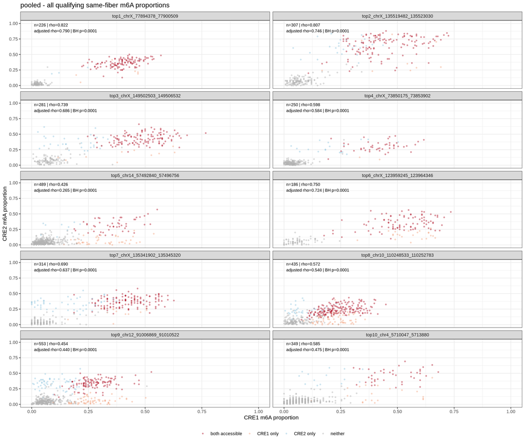

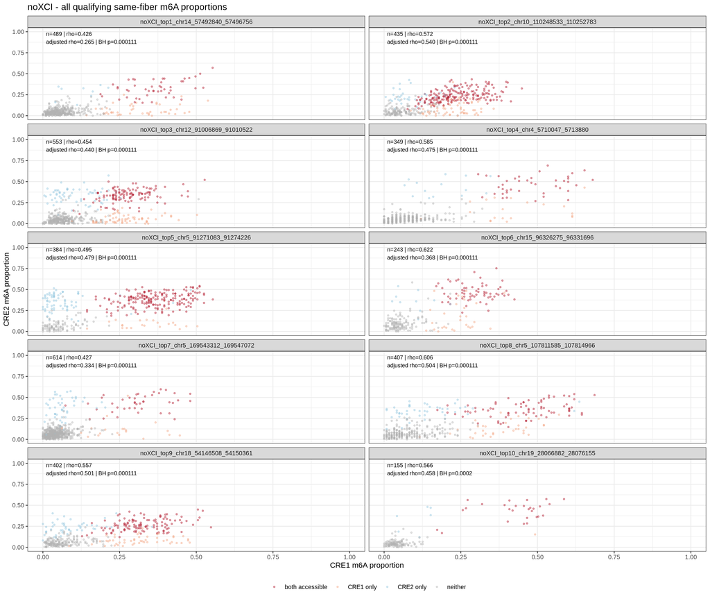

```r
if (isTRUE(params$make_plots)) for (a in analysis_sets) {
  d <- copy(qualifying[analysis == a])
  d[, `:=`(pair_id = factor(pair_id, levels = selected_sets[[a]]$pair_id),
            config = factor(state_labels[state], levels = CONFIG_LEVELS))]
  s <- copy(permutation_statistics[analysis == a])
  s[, pair_id := factor(pair_id, levels = selected_sets[[a]]$pair_id)]
  s[, label := sprintf("n=%d | rho=%.3f\nadjusted rho=%.3f | BH p=%.3g",
    n_qualifying, spearman_rho, within_sample_adjusted_rho, p_positive_BH)]
  p <- ggplot(d, aes(prop1, prop2, colour = config)) +
    geom_point(size = 0.8, alpha = 0.4) +
    geom_text(data = s, aes(x = 0.01, y = 1, label = label), inherit.aes = FALSE,
              hjust = 0, vjust = 1, size = 2.6) +
    scale_colour_manual(values = CONFIG_COLS, drop = FALSE) +
    scale_x_continuous(limits = c(0, 1)) + scale_y_continuous(limits = c(0, 1)) +
    facet_wrap(~pair_id, ncol = 2, drop = FALSE) +
    labs(x = "CRE1 m6A proportion", y = "CRE2 m6A proportion", colour = NULL,
         title = paste(a, "- all qualifying same-fiber m6A proportions")) +
    theme_fiberseq("bw", base_size = 10, overrides = list(legend.position = "bottom"))
  print(p)
  queue_plot(p, paste0(a, "_per_fiber_m6a_scatter"), height = 11)
}
```